# Plotting with ggplot2

We already saw some of R’s built in plotting facilities with the function `plot`. A more recent and much more powerful plotting library is `ggplot2`. `ggplot2` is another mini-language within R, a language for creating plots. It implements ideas from a book called [“The Grammar of Graphics” [url https://www.amazon.com/Grammar-Graphics-Statistics-Computing/dp/0387245448]]. The syntax can be a little strange, but there are plenty of examples in the [online documentation](http://ggplot2.tidyverse.org/reference/).

If `ggplot2` isn’t already installed, we would need to install it.

```r
# install.packages("ggplot2")
# or
# install.packages("tidyverse")
```

`ggplot2` is part of the Tidyverse, so loadinging the `tidyverse` package will load `ggplot2`.

```r
library(tidyverse)
```

Producing a plot with `ggplot2`, we must give three things:

1. A data frame containing our data.
2. How the columns of the data frame can be translated into positions, colors, sizes, and shapes of graphical elements (“aesthetics”).
3. The actual graphical elements to display (“geometric objects”).

# Plotting with ggplot2

We continue using the Gapminder data, which was loaded with:

```r
gap <- read_csv("gapminder.csv")
```

Let’s make our first ggplot.

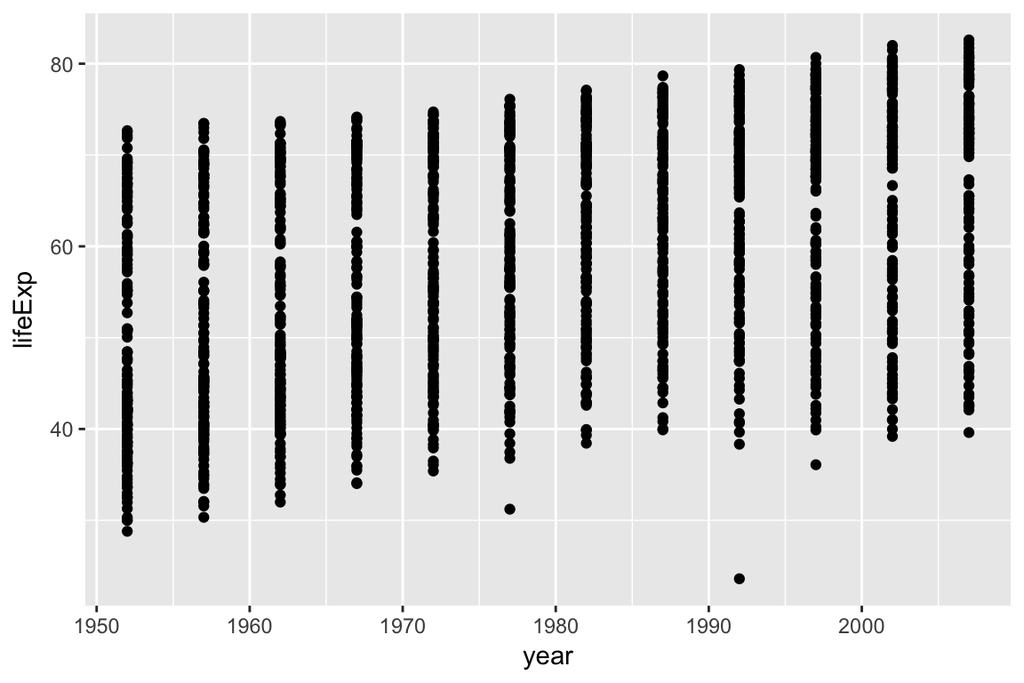

```r
ggplot(gap, aes(x=year, y=lifeExp)) +
    geom_point()
```

The call to `ggplot` and `aes` sets up the basics of how we are going to represent the various columns of the data frame. `aes` defines the “aesthetics”, which is how columns of the data frame map to graphical attributes such as x and y position, color, size, etc. We then literally add layers of graphics to this.

`aes` is another example of magic “non-standard evaluation”, arguments to `aes` may refer to columns of the data frame directly.

Further aesthetics can be used. Any aesthetic can be either numeric or categorical, an appropriate scale will be used.

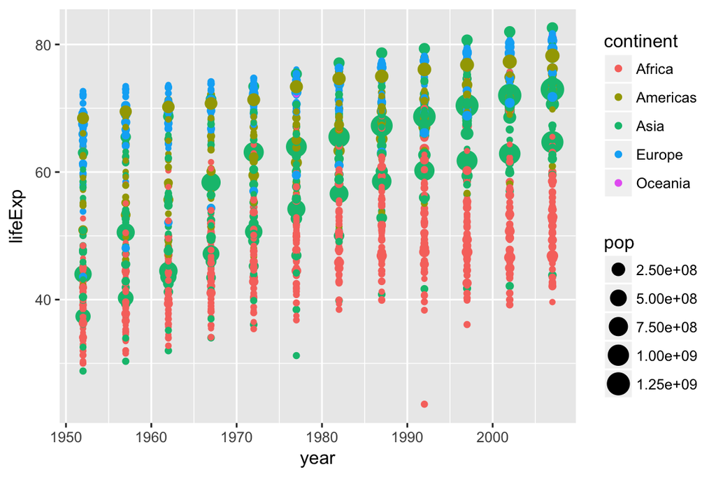

```r
ggplot(gap, aes(x=year, y=lifeExp, color=continent, size=pop)) +
    geom_point()
```

### Challenge

This R code will get the data from the year 2007:

```r
gap2007 <- filter(gap, year == 2007)
```

Create a ggplot of this with `gdpPercap` on the x-axis and `lifeExp` on the y-axis.

# Further geoms

To draw lines, we need to use a “group” aesthetic.

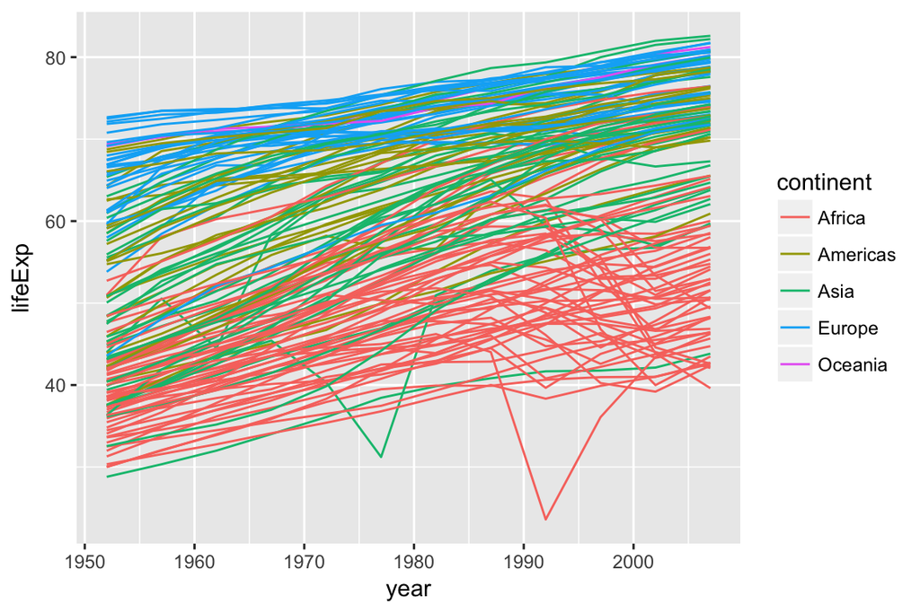

```r
ggplot(gap, aes(x=year, y=lifeExp, group=country, color=continent)) +
    geom_line()
```

A wide variety of geoms are available. Here we show Tukey box-plots. Note again the use of the “group” aesthetic, without this ggplot will just show one big box-plot.

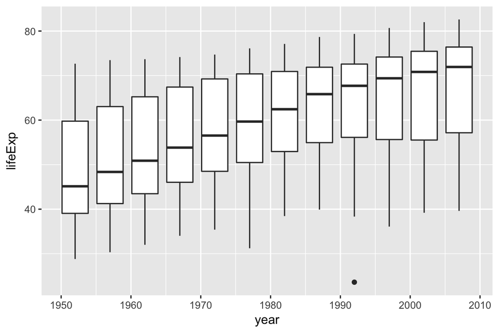

```r
ggplot(gap, aes(x=year, y=lifeExp, group=year)) +
    geom_boxplot()
```

`geom_smooth` can be used to show trends.

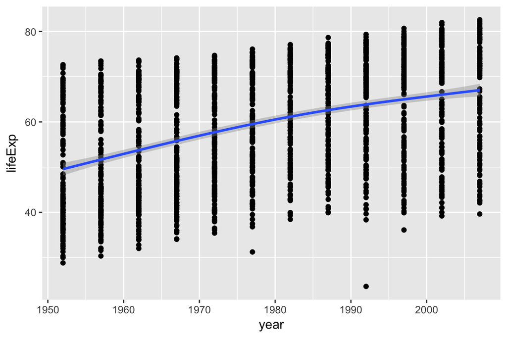

```r
ggplot(gap, aes(x=year, y=lifeExp)) +
    geom_point() +
    geom_smooth()
```

Aesthetics can be specified globally in `ggplot`, or as the first argument to individual geoms. Here, the “group” is applied only to draw the lines, and “color” is used to produce multiple trend lines:

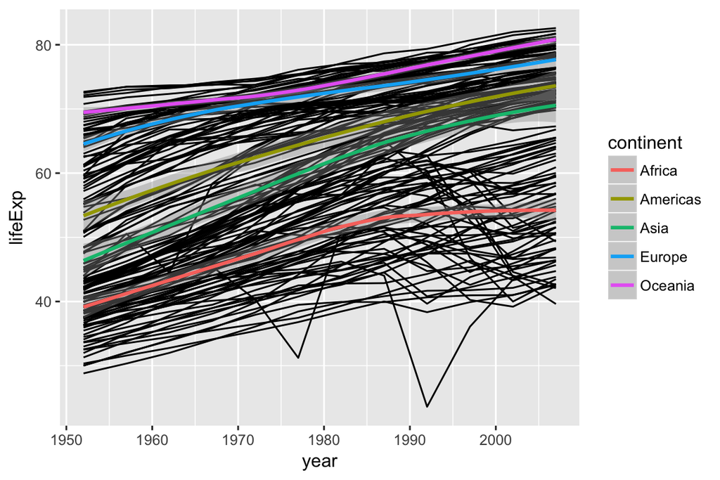

```r
ggplot(gap, aes(x=year, y=lifeExp)) +
    geom_line(aes(group=country)) +
    geom_smooth(aes(color=continent))
```

# Highlighting subsets

Geoms can be added that use a different data frame, using the `data=` argument.

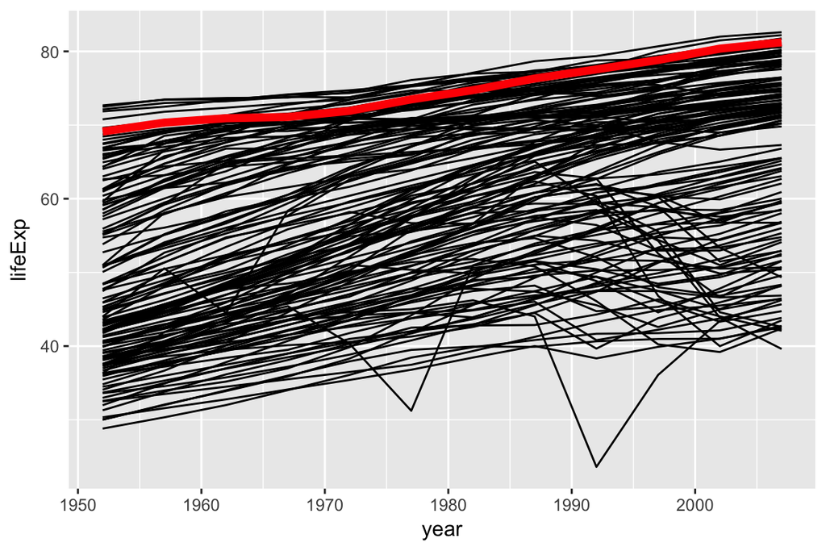

```r
gap_australia <- filter(gap, country == "Australia")

ggplot(gap, aes(x=year, y=lifeExp, group=country)) +
    geom_line() +
    geom_line(data=gap_australia, color="red", size=2)
```

Notice also that the second `geom_line` has some further arguments controlling its appearance. These are **not** aesthetics, they are not a mapping of data to appearance, rather they are direct specification of the appearance. There isn’t an associated scale as when color was an aesthetic.

# Fine-tuning a plot

Adding `labs` to a ggplot adjusts the labels given to the axes and legends. A plot title can also be specified.

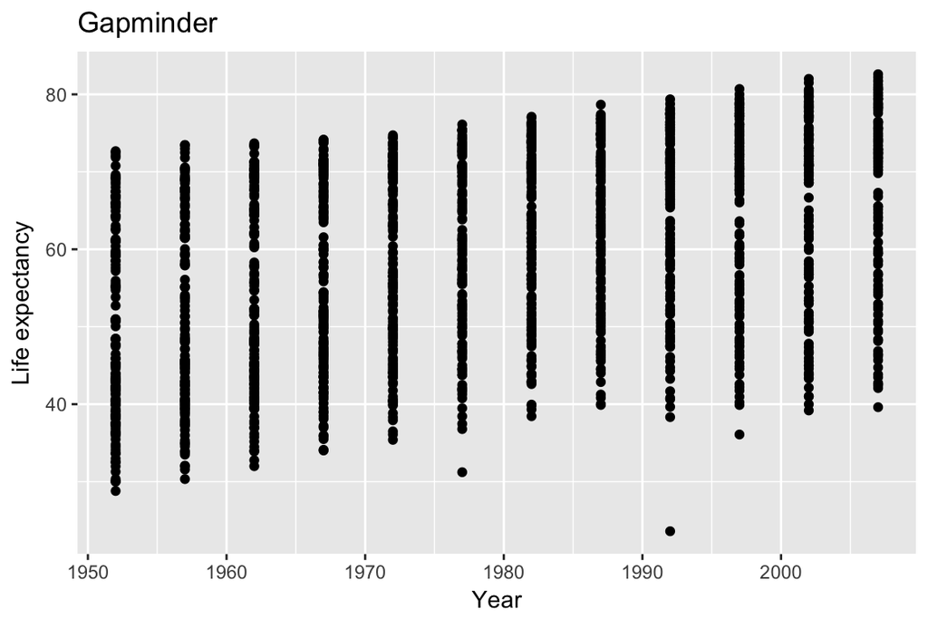

```r
ggplot(gap, aes(x=year, y=lifeExp)) +
    geom_point() +
    labs(x="Year", y="Life expectancy", title="Gapminder")
```

Type `scale_` and press the tab key. You will see functions giving fine-grained controls over various scales (x, y, color, etc). Limits on the scale can be set, as well as transformations (eg log10), and breaks (labelled values).

Suppose we want our y-axis to start at zero.

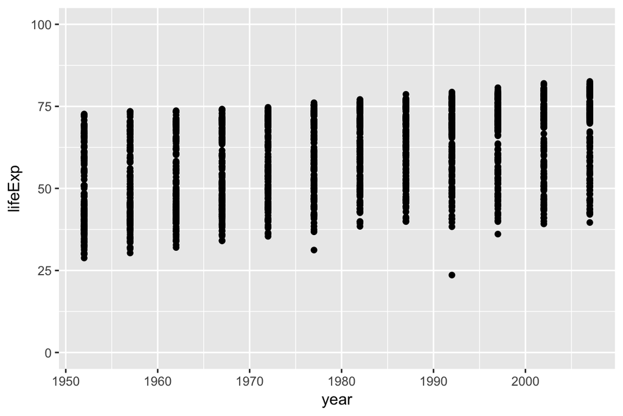

```r
ggplot(gap, aes(x=year, y=lifeExp)) +
    geom_point() +
    scale_y_continuous(limits=c(0,100))
```

The `lims` function can also be used to set limits.

Very fine grained control is possible over the appearance of ggplots, see the ggplot2 documentation for details and further examples.

### Challenge

Continuing with your scatter-plot of the 2007 data, add axis labels to your plot.

Advanced: Give your x axis a log scale (see the documentation on `scale_x_continuous`, specifically the `trans` argument).

# Faceting

Faceting lets us quickly produce a collection of small plots. The plots all have the same scales and the eye can easily compare them.

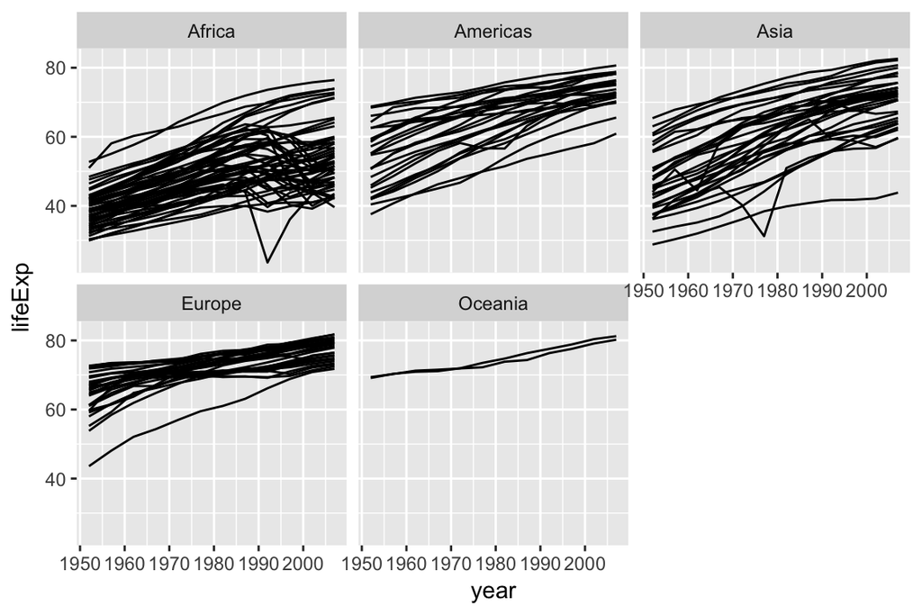

```r
ggplot(gap, aes(x=year, y=lifeExp, group=country)) +
    geom_line() +
    facet_wrap(~ continent)
```

Note the use of `~`, which we’ve not seen before. `~` syntax is used in R to specify dependence on some set of variables, for example when specifying a linear model. Here the information in each plot is dependent on the continent.

### Challenge

Let’s return again to your scatter-plot of the 2007 data.

Adjust your plot to now show data from all years, with each year shown in a separate facet, using `facet_wrap(~ year)`.

Advanced: Highlight Australia in your plot.

# Saving ggplots

The act of plotting a ggplot is actually triggered when it is printed. In an interactive session we are automatically printing each value we calculate, but if you are using a for loop, or other R programming constructs, you might need to explcitly `print( )` the plot.

Ggplots can be saved using `ggsave`.

```r
# Plot created but not shown.
p <- ggplot(gap, aes(x=year, y=lifeExp)) + geom_point()

# Only when we try to look at the value p is it shown
p

# Alternatively, we can explicitly print it
print(p)

# To save to a file
ggsave("test.png", p)
```

[figure not shown]